# Lending Club Loans' Default Prediction--By Clara Liu

# Contents

1. Introduction 2. Import Raw Data & Initial Description 3. Target Variable 3.1 Loan Status Distribution 3.2 Create Target Variable 4. Data Cleaning & EDA 4.1 Remove features which are missing >50% of the values 4.2 Remove future data 4.3 Exploratory Data Analysis 5. Feature Engineering 5.1 One Hot Encoding for Categorical Features 5.2 Split Training and Test Data 5.3 Fill in Missing Values 5.4 Feature Scaling 6. Modeling 6.1 Logistic Regression 6.2 Random Forest 6.3 Extreme Gradient Boosting 7. Conclusion

# 1. Introduction

Data is from Lending Club, containing information for their loan portfolio between 2015 and mid-2016. Lending Club provides loans for crerevol_bal card refinance, debt consolidation, and various of other purpose forms of personal loans.

The dataset contains information about each loan, including funded amount, interest rate, term, installment, and status. It also contains a lot of information about the loan recipient, such as housing status, employment status, purpose of loan, location, etc.

The goal of this project is to build a model to predict the probability of each loan defaulting before it is issued.

```python
# import basic packages
import pandas as pd
import numpy as np
import matplotlib.pyplot as plt
import seaborn as sns
import math
sns.set_style('whitegrid')
%matplotlib inline

#import preprocessing tools
from sklearn.preprocessing import LabelBinarizer
from sklearn.model_selection import train_test_split
from  sklearn.preprocessing import StandardScaler
from sklearn.preprocessing import Imputer

#import Machine Learning models
import xgboost as xgb
from sklearn.ensemble import RandomForestRegressor
from sklearn.linear_model import LogisticRegression
from sklearn.ensemble import RandomForestClassifier
from sklearn.neighbors import KNeighborsClassifier
from sklearn.neural_network import MLPClassifier

#import hyperparameter optimization tools
from sklearn.model_selection import GridSearchCV, cross_val_score, StratifiedKFold
from sklearn.model_selection import RandomizedSearchCV

#import accuracy metrics
from sklearn import metrics
from sklearn.metrics import confusion_matrix,roc_auc_score,accuracy_score, roc_curve
from sklearn.metrics import classification_report

#clean the work space
import warnings
warnings.filterwarnings("ignore")
```

# 2. Initial description

Import the raw data and have a basic understanding of the variables in the data set. Created a column "loan_id" as the unique identifier for each loan. (This is useful to match records after modeling. Maybe not necessary in this project but it's always better to have a unique id column)

```python
df = pd.read_excel('../LoadData15_16.xlsx')
df.info()
```

```
<class 'pandas.core.frame.DataFrame'>
RangeIndex: 345941 entries, 0 to 345940
Columns: 124 entries, loan_amnt to hardship_last_payment_amount
dtypes: float64(63), int64(41), object(20)
memory usage: 327.3+ MB
```

```python
df.head()#have a look at the data
```

|  | loan_amnt | term | int_rate | installment | emp_title | emp_length | home_ownership | annual_inc | verification_status | issue_d | ... | hardship_amount | hardship_start_date | hardship_end_date | payment_plan_start_date | hardship_length | hardship_dpd | hardship_loan_status | orig_projected_additional_accrued_interest | hardship_payoff_balance_amount | hardship_last_payment_amount |
| --- | --- | --- | --- | --- | --- | --- | --- | --- | --- | --- | --- | --- | --- | --- | --- | --- | --- | --- | --- | --- | --- |
| 0 | 25000 | 36 months | 0.0749 | 777.55 | Sales Manager | 10+ years | MORTGAGE | 109000.0 | Not Verified | 42339 | ... | NaN | NaN | NaN | NaN | NaN | NaN | NaN | NaN | NaN | NaN |
| 1 | 23975 | 60 months | 0.1989 | 633.73 | Principal | 10+ years | RENT | 70000.0 | Not Verified | 42339 | ... | NaN | NaN | NaN | NaN | NaN | NaN | NaN | NaN | NaN | NaN |
| 2 | 7200 | 36 months | 0.1148 | 237.36 | Legal Administrative Assistant | 10+ years | MORTGAGE | 72500.0 | Verified | 42339 | ... | NaN | NaN | NaN | NaN | NaN | NaN | NaN | NaN | NaN | NaN |
| 3 | 21875 | 36 months | 0.1199 | 726.46 | Wire Technician | < 1 year | RENT | 47590.0 | Source Verified | 42339 | ... | NaN | NaN | NaN | NaN | NaN | NaN | NaN | NaN | NaN | NaN |
| 4 | 20000 | 36 months | 0.1288 | 672.73 | President | 10+ years | MORTGAGE | 145000.0 | Not Verified | 42339 | ... | NaN | NaN | NaN | NaN | NaN | NaN | NaN | NaN | NaN | NaN |

5 rows × 124 columns

```python
df.reset_index(inplace = True)
df.rename(columns = {'index': 'loan_id'}, inplace = True)
```

125 columns in total

```python
df.describe()# get the statistics of numeric columns
```

|  | loan_id | loan_amnt | int_rate | installment | annual_inc | issue_d | url | dti | delinq_2yrs | earliest_cr_line | ... | deferral_term | hardship_amount | hardship_start_date | hardship_end_date | payment_plan_start_date | hardship_length | hardship_dpd | orig_projected_additional_accrued_interest | hardship_payoff_balance_amount | hardship_last_payment_amount |
| --- | --- | --- | --- | --- | --- | --- | --- | --- | --- | --- | --- | --- | --- | --- | --- | --- | --- | --- | --- | --- | --- |
| count | 345941.000000 | 345941.000000 | 345941.000000 | 345941.000000 | 3.459410e+05 | 345941.000000 | 0.0 | 345926.000000 | 345941.000000 | 345941.000000 | ... | 151.0 | 151.000000 | 151.000000 | 151.000000 | 151.000000 | 151.0 | 151.000000 | 115.000000 | 151.000000 | 151.000000 |
| mean | 172970.000000 | 15202.894496 | 0.124686 | 444.683129 | 7.786355e+04 | 42275.362203 | NaN | 19.141525 | 0.344582 | 36124.118306 | ... | 3.0 | 137.712053 | 42861.099338 | 42932.350993 | 42869.655629 | 3.0 | 18.536424 | 418.630957 | 10861.955166 | 180.707152 |
| std | 99864.709074 | 8687.596736 | 0.044985 | 251.773331 | 7.101208e+04 | 151.938889 | NaN | 9.336536 | 0.917791 | 2804.791281 | ... | 0.0 | 116.443849 | 25.238530 | 31.578727 | 26.700324 | 0.0 | 7.997312 | 372.086326 | 7176.466213 | 172.562457 |
| min | 0.000000 | 1000.000000 | 0.053200 | 30.120000 | 0.000000e+00 | 42005.000000 | NaN | 0.000000 | 0.000000 | 18264.000000 | ... | 3.0 | 7.640000 | 42767.000000 | 42795.000000 | 42767.000000 | 3.0 | 0.000000 | 22.920000 | 627.960000 | 2.170000 |
| 25% | 86485.000000 | 8275.000000 | 0.091600 | 260.970000 | 4.700000e+04 | 42156.000000 | NaN | 12.480000 | 0.000000 | 34669.000000 | ... | 3.0 | 48.855000 | 42856.000000 | 42917.000000 | 42856.000000 | 3.0 | 13.000000 | 142.665000 | 5192.005000 | 54.850000 |
| 50% | 172970.000000 | 14000.000000 | 0.119900 | 385.620000 | 6.500000e+04 | 42278.000000 | NaN | 18.490000 | 0.000000 | 36678.000000 | ... | 3.0 | 93.120000 | 42856.000000 | 42948.000000 | 42887.000000 | 3.0 | 20.000000 | 274.020000 | 8665.620000 | 119.560000 |
| 75% | 259455.000000 | 20000.000000 | 0.153100 | 587.340000 | 9.300000e+04 | 42401.000000 | NaN | 25.290000 | 0.000000 | 38078.000000 | ... | 3.0 | 194.160000 | 42887.000000 | 42948.000000 | 42887.000000 | 3.0 | 25.500000 | 582.030000 | 15716.460000 | 257.800000 |
| max | 345940.000000 | 40000.000000 | 0.309900 | 1569.110000 | 9.225000e+06 | 42522.000000 | NaN | 999.000000 | 22.000000 | 41395.000000 | ... | 3.0 | 506.890000 | 42948.000000 | 43040.000000 | 42979.000000 | 3.0 | 29.000000 | 1520.670000 | 33585.720000 | 777.280000 |

8 rows × 105 columns

Most variables are numeric. Some are categorical.

```python
pd.DataFrame(sorted((df.isnull().sum()/len(df)).items(), key = lambda x:x[1], reverse = True), columns = ['column', 'missing rate'])# check missing values
```

|  | column | missing rate |
| --- | --- | --- |
| 0 | url | 1.000000 |
| 1 | sec_app_inq_last_6mths | 1.000000 |
| 2 | sec_app_mort_acc | 1.000000 |
| 3 | sec_app_open_il_6m | 1.000000 |
| 4 | sec_app_chargeoff_within_12_mths | 1.000000 |
| 5 | desc | 0.999896 |
| 6 | orig_projected_additional_accrued_interest | 0.999668 |
| 7 | hardship_type | 0.999564 |
| 8 | hardship_reason | 0.999564 |
| 9 | hardship_status | 0.999564 |
| 10 | deferral_term | 0.999564 |
| 11 | hardship_amount | 0.999564 |
| 12 | hardship_start_date | 0.999564 |
| 13 | hardship_end_date | 0.999564 |
| 14 | payment_plan_start_date | 0.999564 |
| 15 | hardship_length | 0.999564 |
| 16 | hardship_dpd | 0.999564 |
| 17 | hardship_loan_status | 0.999564 |
| 18 | hardship_payoff_balance_amount | 0.999564 |
| 19 | hardship_last_payment_amount | 0.999564 |
| 20 | dti_joint | 0.993120 |
| 21 | annual_inc_joint | 0.993109 |
| 22 | verification_status_joint | 0.993109 |
| 23 | mths_since_last_record | 0.822337 |
| 24 | mths_since_recent_bc_dlq | 0.745656 |
| 25 | mths_since_last_major_derog | 0.713321 |
| 26 | il_util | 0.667487 |
| 27 | mths_since_recent_revol_delinq | 0.641725 |
| 28 | mths_since_rcnt_il | 0.625667 |
| 29 | all_util | 0.615316 |
| ... | ... | ... |
| 95 | tot_cur_bal | 0.000000 |
| 96 | total_rev_hi_lim | 0.000000 |
| 97 | acc_open_past_24mths | 0.000000 |
| 98 | avg_cur_bal | 0.000000 |
| 99 | chargeoff_within_12_mths | 0.000000 |
| 100 | delinq_amnt | 0.000000 |
| 101 | mo_sin_old_rev_tl_op | 0.000000 |
| 102 | mo_sin_rcnt_rev_tl_op | 0.000000 |
| 103 | mo_sin_rcnt_tl | 0.000000 |
| 104 | mort_acc | 0.000000 |
| 105 | num_accts_ever_120_pd | 0.000000 |
| 106 | num_actv_bc_tl | 0.000000 |
| 107 | num_actv_rev_tl | 0.000000 |
| 108 | num_bc_sats | 0.000000 |
| 109 | num_bc_tl | 0.000000 |
| 110 | num_il_tl | 0.000000 |
| 111 | num_op_rev_tl | 0.000000 |
| 112 | num_rev_tl_bal_gt_0 | 0.000000 |
| 113 | num_sats | 0.000000 |
| 114 | num_tl_30dpd | 0.000000 |
| 115 | num_tl_90g_dpd_24m | 0.000000 |
| 116 | num_tl_op_past_12m | 0.000000 |
| 117 | pct_tl_nvr_dlq | 0.000000 |
| 118 | pub_rec_bankruptcies | 0.000000 |
| 119 | tax_liens | 0.000000 |
| 120 | tot_hi_cred_lim | 0.000000 |
| 121 | total_bal_ex_mort | 0.000000 |
| 122 | total_bc_limit | 0.000000 |
| 123 | total_il_high_credit_limit | 0.000000 |
| 124 | hardship_flag | 0.000000 |

125 rows × 2 columns

We can see that some variables are missing most of values such as hardship related features.

# 3. Create target variable

The most default relevant variable is 'loan_status'. I will create a binary target variable based on loan_status.

# 3.1 Loan Status Distribution

Let's have a look at the distribution of loan status

```python
df['loan_status'].value_counts()
```

```
Current        208906
Fully Paid     101345
Charged Off     35682
Default             8
Name: loan_status, dtype: int64
```

Charged off loans can be seen as default. Fully paid loans are definitely not default. Most of the records we have are current loans. We are not sure whether theya re default or not.

# 3.2 Create target variable

Here we want to choose to keep loans that are fully paid or default.

```python
def change_loan_status(x):
    if x == 'Charged Off' or x == 'Default': return 1
    elif x == 'Fully Paid': return 0
    else: return x

def predict_default(x):
    if x>0: return 1
    else: return 0
df['default']=df['loan_status'].apply(lambda x: change_loan_status(x))
df['default'].value_counts()
```

```
Current    208906
0          101345
1           35690
Name: default, dtype: int64
```

```python
df = df[(df['default']==0)|(df['default']==1)]
```

# 4. Data Cleaning

This part includes dealing with missing values and removing "future variables"

# 4.1 Remove features which are missing >50% of the values

First I will delete the features missing too many values. They will not be predictive.

```python
missing_prop = df.isnull().mean()
drop_list = sorted(missing_prop[missing_prop > 0.50].index)
drop_list
```

```
['all_util',
 'annual_inc_joint',
 'deferral_term',
 'desc',
 'dti_joint',
 'hardship_amount',
 'hardship_dpd',
 'hardship_end_date',
 'hardship_last_payment_amount',
 'hardship_length',
 'hardship_loan_status',
 'hardship_payoff_balance_amount',
 'hardship_reason',
 'hardship_start_date',
 'hardship_status',
 'hardship_type',
 'il_util',
 'inq_fi',
 'inq_last_12m',
 'max_bal_bc',
 'mths_since_last_major_derog',
 'mths_since_last_record',
 'mths_since_rcnt_il',
 'mths_since_recent_bc_dlq',
 'mths_since_recent_revol_delinq',
 'next_pymnt_d',
 'open_acc_6m',
 'open_il_12m',
 'open_il_24m',
 'open_il_6m',
 'open_rv_12m',
 'open_rv_24m',
 'orig_projected_additional_accrued_interest',
 'payment_plan_start_date',
 'sec_app_chargeoff_within_12_mths',
 'sec_app_inq_last_6mths',
 'sec_app_mort_acc',
 'sec_app_open_il_6m',
 'total_bal_il',
 'total_cu_tl',
 'url',
 'verification_status_joint']
```

```python
#drop these columns
df.drop(drop_list, axis=1, inplace=True)
```

New data's shape

```python
df.shape
```

```
(137035, 84)
```

# 4.2 Remove future data

There are many features that we can only get after the loan is issued but the point here is to predict default risk so we should only keep features we can get before issuing the loan.

Create a future feature list. I checked the lending club data dictionary and found some future features. They should be eliminated from our dataset.

```python
future_features=['acc_now_delinq',
 'acc_open_past_24mths',
 'avg_cur_bal',
 'bc_open_to_buy',
 'bc_util',
 'chargeoff_within_12_mths',
 'collection_recovery_fee',
 'collections_12_mths_ex_med',
 'delinq_2yrs',
 'delinq_amnt',
 'hardship_flag',
 'inq_last_6mths',
 'issue_d',
 'last_pymnt_amnt',
 'last_pymnt_d',
 'last_credit_pull_d',
 'mo_sin_old_il_acct',
 'mo_sin_old_rev_tl_op',
 'mo_sin_rcnt_rev_tl_op',
 'mo_sin_rcnt_tl',
 'mort_acc',
 'mths_since_last_delinq',
 'mths_since_recent_bc',
 'mths_since_recent_inq',
 'num_accts_ever_120_pd',
 'num_actv_revol_tl',
 'num_op_revol_tl',
 'num_actv_revol_tl',
 'num_bc_sats',
 'num_bc_tl',
 'num_il_tl',
 'num_rev_accts',
 'num_revol_tl_bal_gt_0',
 'num_sats',
 'num_tl_120dpd_2m',
 'num_tl_30dpd',
 'num_tl_90g_dpd_24m',
 'num_tl_op_past_12m',
 'num_rev_tl_bal_gt_0'
 'open_acc',
 'out_prncp',
 'out_prncp_inv',
 'pct_tl_nvr_dlq',
 'percent_bc_gt_75',
 'pub_rec_bankruptcies',
 'recoveries',
 'tax_liens',
 'tot_coll_amt',
 'tot_hi_cred_lim',
 'total_bal_ex_mort',
 'total_bc_limit',
 'tot_cur_bal',
 'total_acc',
 'total_pymnt',
 'total_pymnt_inv',
 'total_rec_int',
 'total_rec_late_fee',
 'total_rec_prncp',
 'total_il_high_credit_limit']
```

```python
df.columns
```

[output not shown]

# 4.3 Exploratory Data Analysis

Here we will check the remained features' distributions one by one. I will clean and transform some variables when needed. First create a function to help to visualize each feature.

```python
# create a function to visualize each feature
def plot_var(col_name, full_name, continuous):
    """
    col_name is the original variable name
    full_name is the user friendly variable name
    continuous is True for continuous variables
    False for categorical variables
    """
    fig, (ax1, ax2) = plt.subplots(2, 1, sharex=False, figsize=(25,20))

    # plot1: counts distribution of the variable
    if continuous:
        sns.distplot(df.loc[df[col_name].notnull(), col_name], kde=False, ax=ax1)
    else:
        sns.countplot(df[col_name], order=sorted(df[col_name].unique()), color='#5975A4', saturation=1, ax=ax1)
    ax1.set_xlabel(full_name)
    ax1.set_ylabel('Count')
    ax1.set_title(full_name)


    # plot2: bar plot of the variable grouped by loan_status
    if continuous:
        sns.boxplot(x='default', y=col_name, data=df, ax=ax2)
        ax2.set_ylabel('')
        ax2.set_title(full_name + 'Grouped by Loan Status')
    else:
        default_rates = df.groupby(col_name)['default'].value_counts(normalize=True)[:,1]
        sns.barplot(x=default_rates.index, y=default_rates.values, color='#5975A4', saturation=1, ax=ax2)
        ax2.set_ylabel('Fraction of Loans default')
        ax2.set_title('Default Rate by ' + full_name)
        ax2.set_xlabel(full_name)

    # plot3: kde plot of the variable gropued by loan_status
    if continuous:
        facet = sns.FacetGrid(df, hue = 'default', size=3, aspect=4)
        facet.map(sns.kdeplot, col_name, shade=True)
        #facet.set(xlim=(df[col_name].min(), df[col_name].max()))
        facet.add_legend()
    else:
        fig = plt.figure(figsize=(16,3))
        sns.countplot(x=col_name, hue='default', data=df, order=sorted(df[col_name].unique()))

    plt.tight_layout()
```

# Loan Amount

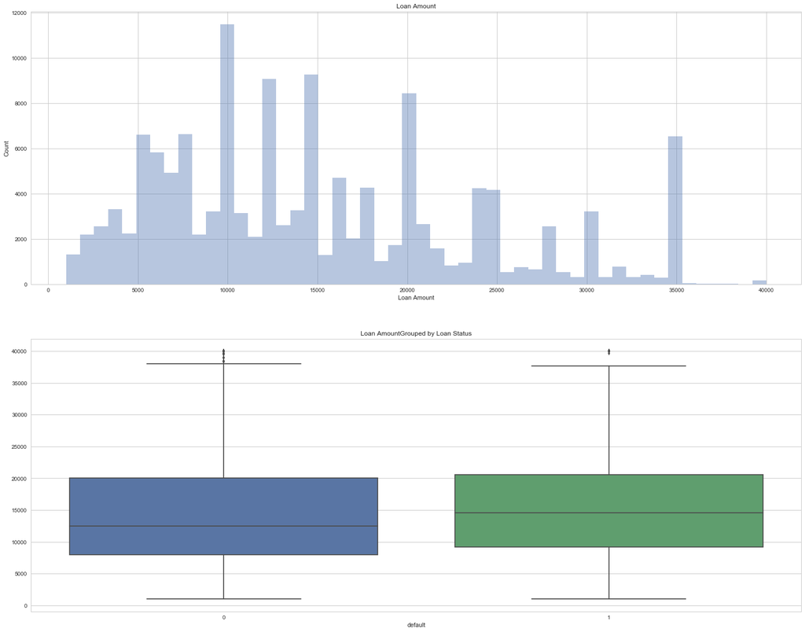

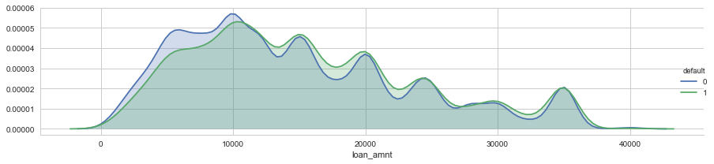

```python
plot_var('loan_amnt','Loan Amount',True)
```

# Term

```python
df['term'].value_counts()
```

```
 36 months    98896
 60 months    38139
Name: term, dtype: int64
```

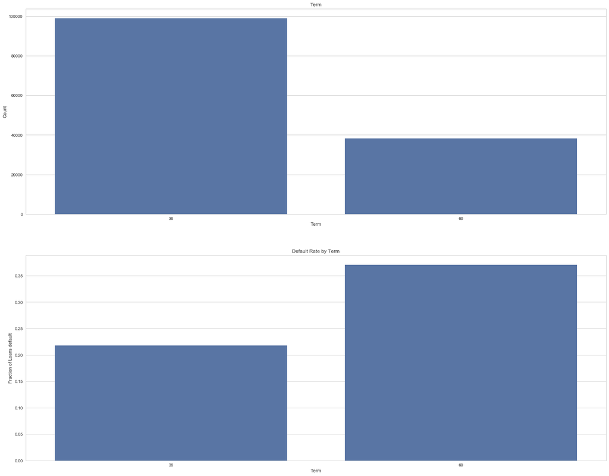

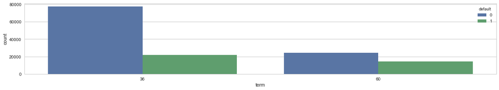

```python
# transfer term
df['term']=df['term'].apply(lambda s: int(s.split()[0]))
plot_var('term','Term',False)
```

# Interest Rate

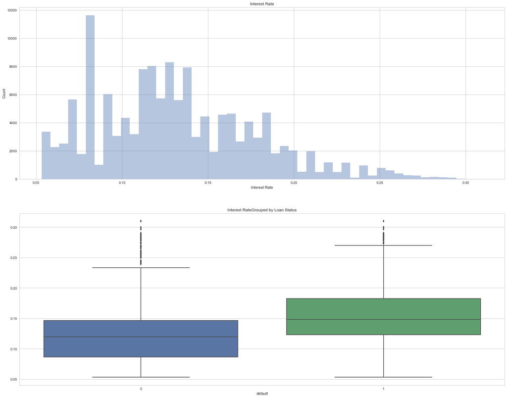

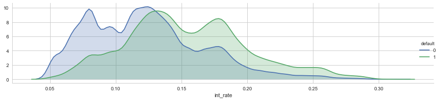

```python
plot_var('int_rate','Interest Rate',True)
```

# Installment

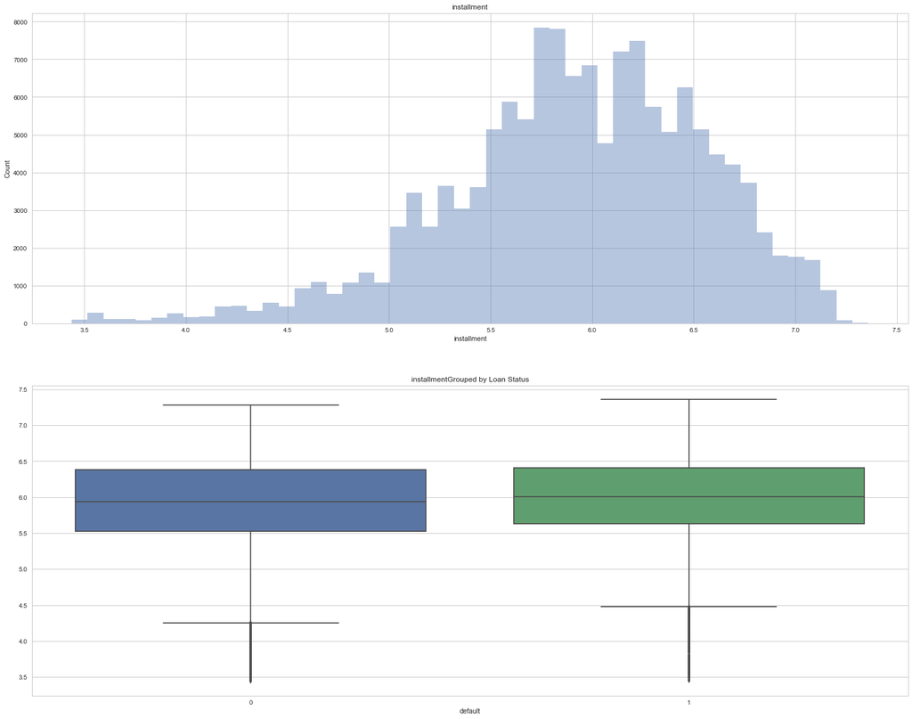

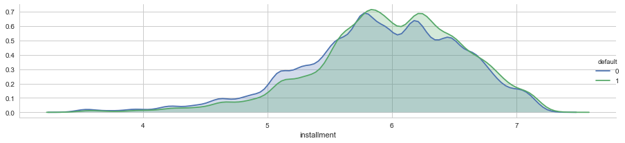

```python
df['installment'] = df['installment'].apply(lambda x: math.log(x+1))
plot_var('installment','installment',True)
```

# Job Title

```python
pd.DataFrame(sorted(df['emp_title'].value_counts().items(), key = lambda x:x[1], reverse = True), columns = ['Emp_title', 'count'])
```

|  | Emp_title | count |
| --- | --- | --- |
| 0 | Teacher | 2331 |
| 1 | Manager | 2302 |
| 2 | Supervisor | 1089 |
| 3 | Owner | 1071 |
| 4 | Registered Nurse | 979 |
| 5 | RN | 958 |
| 6 | Sales | 911 |
| 7 | Driver | 813 |
| 8 | Project Manager | 797 |
| 9 | Director | 638 |
| 10 | Office Manager | 637 |
| 11 | General Manager | 610 |
| 12 | manager | 562 |
| 13 | Engineer | 552 |
| 14 | teacher | 496 |
| 15 | owner | 490 |
| 16 | driver | 475 |
| 17 | Vice President | 462 |
| 18 | Operations Manager | 433 |
| 19 | President | 429 |
| 20 | Accountant | 404 |
| 21 | Account Manager | 380 |
| 22 | Administrative Assistant | 367 |
| 23 | Sales Manager | 364 |
| 24 | sales | 352 |
| 25 | Attorney | 341 |
| 26 | Police Officer | 332 |
| 27 | Analyst | 327 |
| 28 | Executive Assistant | 314 |
| 29 | supervisor | 311 |
| ... | ... | ... |
| 48964 | Shift Manager | 1 |
| 48965 | Patient services/navigator | 1 |
| 48966 | CONFIGURATION SPECIALIST | 1 |
| 48967 | Senior Real Estate Transactions Manager | 1 |
| 48968 | Senior Research Engineer | 1 |
| 48969 | Insurance cordinator | 1 |
| 48970 | Medicaid Analyst | 1 |
| 48971 | Manager of Iperations | 1 |
| 48972 | Disability exonerated | 1 |
| 48973 | Customer Service Rep Warranty | 1 |
| 48974 | Credit Administration | 1 |
| 48975 | Special Accounts Agent | 1 |
| 48976 | CNC MACHINIST | 1 |
| 48977 | Actuarial Associate | 1 |
| 48978 | compliance office | 1 |
| 48979 | RN Liaison | 1 |
| 48980 | Health Science Specialist/PACS Admin | 1 |
| 48981 | evs worker 1 | 1 |
| 48982 | lineman/boat operator | 1 |
| 48983 | WAREHOUSE ASSOCIATE | 1 |
| 48984 | Liability adjuster | 1 |
| 48985 | RETAIL SALES CONSULTANT | 1 |
| 48986 | Driver/Routing manager | 1 |
| 48987 | equipment opperator | 1 |
| 48988 | QC/R&D | 1 |
| 48989 | Lead analyst | 1 |
| 48990 | Grant Director | 1 |
| 48991 | Manager - IT | 1 |
| 48992 | Cyber Risk Manager | 1 |
| 48993 | Senior Fraud Specialist | 1 |

48994 rows × 2 columns

There are many unique titles. We don't want too many unique values. Noticed that there are many managers and supervisors. I decided to group it by different level of employment. Also need to change titles to lowercase because of unconsistency of the values.

```python
def group_title(title):
    if not isinstance(title, str):
        return 'unkown employment'
    elif 'director' in title or 'president' in title or 'leader' in title or 'ceo' in title:
        return 'business senior manager'
    elif 'manage' in title or 'supervisor' in title or 'administrator' in title:
        return 'business manager'
    elif 'owner' in title:
        return 'business owner'
    elif 'teacher' in title:
        return 'teacher'
    elif 'driver' in title:
        return 'driver'
    elif 'assistant' in title or 'associate' in title or 'secretary' in title:
        return 'assistant'
    elif 'law' in title or 'attorney' in title or 'judge' in  title:
        return 'lawyer'
    elif 'nurse' in title or 'rn' in title or 'doctor' in title:
        return 'nurse & doctor'
    elif 'engineer' in title or 'software' in title:
        return 'engineer'
    elif 'analyst' in title or 'consultant' in title or 'specialist' in title or 'advisor' in title or 'account' in title:
        return 'technical employee'
    elif 'officer' in  title:
        return 'officer'
    elif 'tech' in title or 'mechanic' in title or 'operate' in title or 'electrician' in title or 'maintenance' in title or 'therapist' in title:
        return 'technician'
    elif 'sale' in  title or 'cash' in  title or 'clerk' in title:
        return 'sales'
    elif 'agent' in title:
        return 'agent'
    else: return 'other title'

df['group_emp_title']= df['emp_title'].apply(lambda x: group_title(x))
df['group_emp_title'].value_counts()
```

[output not shown]

[figure not shown]

[figure not shown]

```python
plot_var('group_emp_title','Group Emp Title',False)
```

# Employment Length

```python
df['emp_length'].value_counts()
```

```
10+ years    45223
2 years      12600
< 1 year     11231
3 years      10929
1 year        9208
5 years       8309
4 years       8090
n/a           7747
8 years       6921
7 years       5693
9 years       5553
6 years       5531
Name: emp_length, dtype: int64
```

Notice that it's not pure number. Convert it to number here:

```python
def employ_length(x):
    if x == 'n/a' : return x
    if x.split()[0]=='10+':return 10
    elif x.split()[0]=='<':return 0
    else:
        return int(x.split()[0])
df['emp_length'] = df['emp_length'].apply(lambda x:employ_length(x))
df['emp_length'].replace('n/a', df[df['emp_length']!='n/a']['emp_length'].mean(), inplace = True)
```

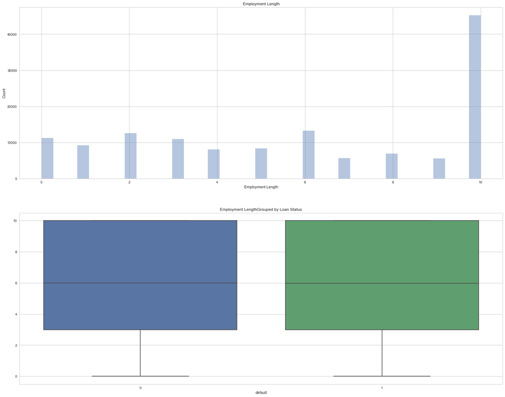

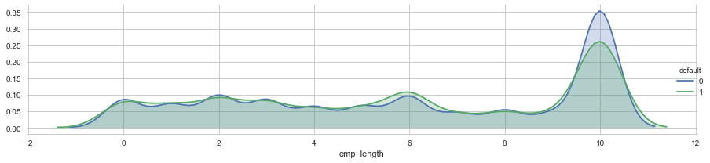

```python
plot_var('emp_length','Employment Length', True)
```

# Home Ownership

```python
df['home_ownership'].value_counts()
```

```
MORTGAGE    68240
RENT        53368
OWN         15427
Name: home_ownership, dtype: int64
```

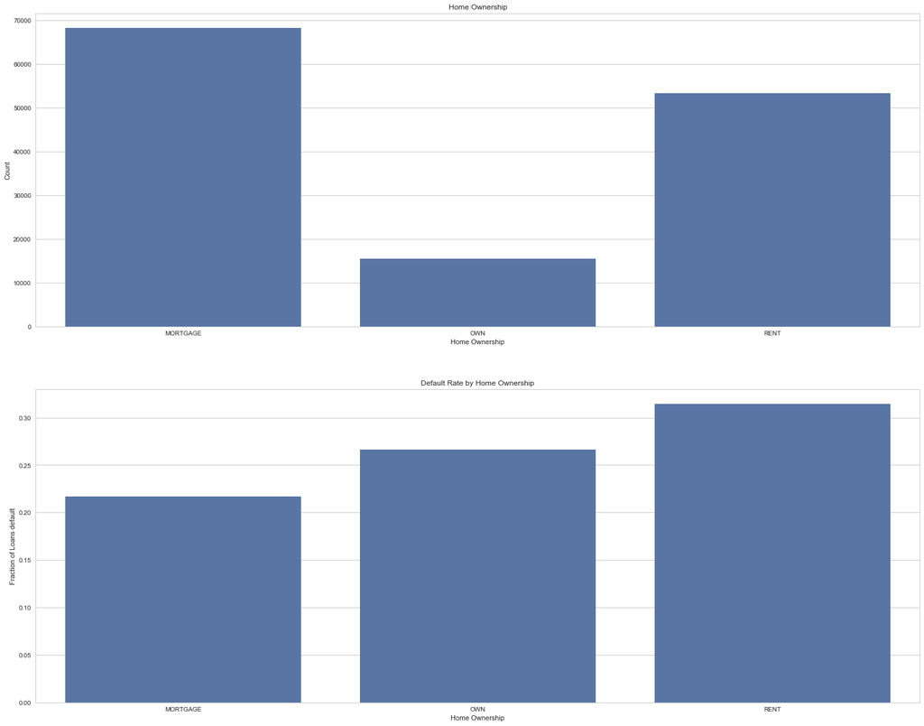

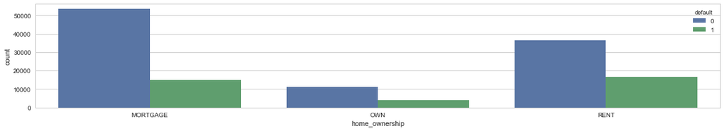

```python
plot_var('home_ownership','Home Ownership',False)
```

# Annual Income

Define cut outlier function

```python
def cut_outlier(high, low, x):
    if x >= high: return high
    elif x<= low: return low
    else: return x
```

Cut extreme values and convert it to log value

```python
df.columns
```

```
Index(['loan_id', 'loan_amnt', 'term', 'int_rate', 'installment', 'emp_title',
       'emp_length', 'home_ownership', 'annual_inc', 'verification_status',
       'loan_status', 'pymnt_plan', 'purpose', 'title', 'zip_code',
       'addr_state', 'dti', 'earliest_cr_line', 'pub_rec', 'revol_bal',
       'revol_util', 'initial_list_status', 'last_credit_pull_d',
       'policy_code', 'application_type', 'total_rev_hi_lim',
       'mo_sin_old_rev_tl_op', 'mo_sin_rcnt_rev_tl_op', 'num_actv_rev_tl',
       'num_op_rev_tl', 'num_rev_accts', 'num_rev_tl_bal_gt_0',
       'pub_rec_bankruptcies', 'total_il_high_credit_limit', 'default',
       'group_emp_title'],
      dtype='object')
```

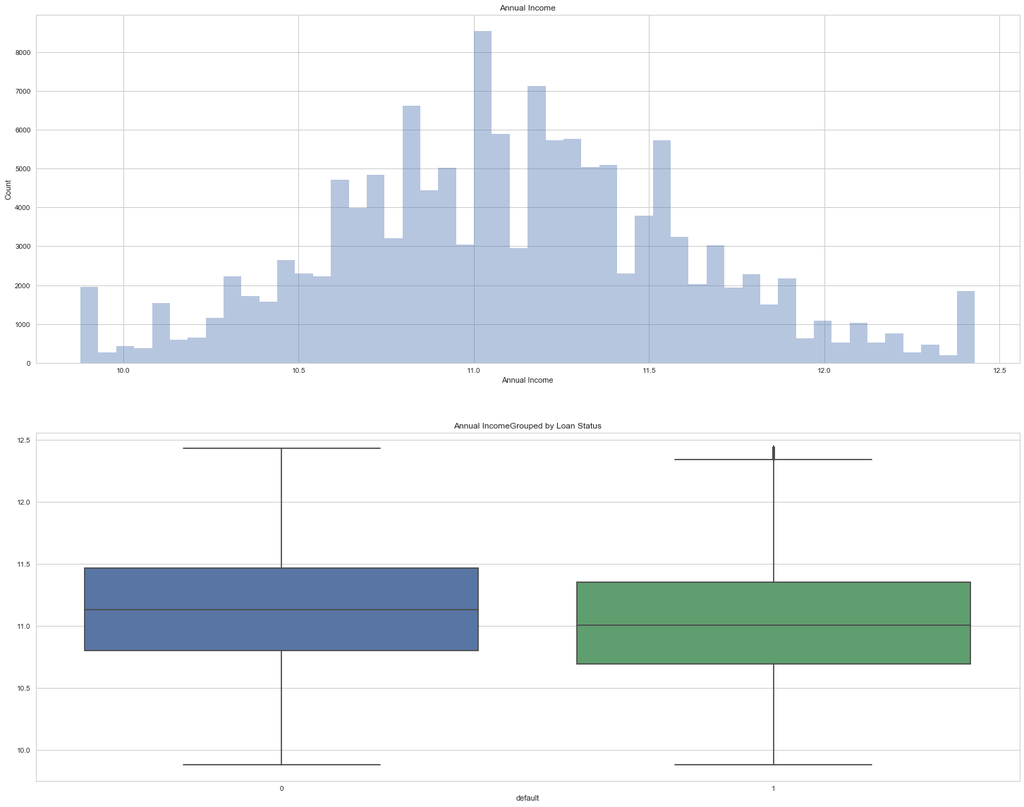

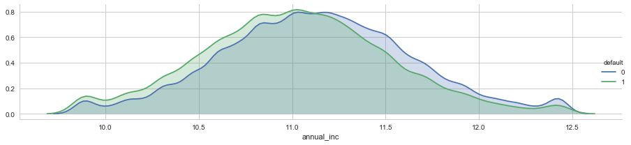

```python
high = np.percentile(df['annual_inc'], 99)
low = np.percentile(df['annual_inc'], 1)
df['annual_inc'] = df['annual_inc'].apply(lambda x: cut_outlier(high, low, x))
df['annual_inc'] = df['annual_inc'].apply(lambda x: math.log(x+1))
plot_var('annual_inc','Annual Income',True)
```

# Verification Status

```python
df['verification_status'].value_counts()
```

```
Source Verified    57700
Verified           41460
Not Verified       37875
Name: verification_status, dtype: int64
```

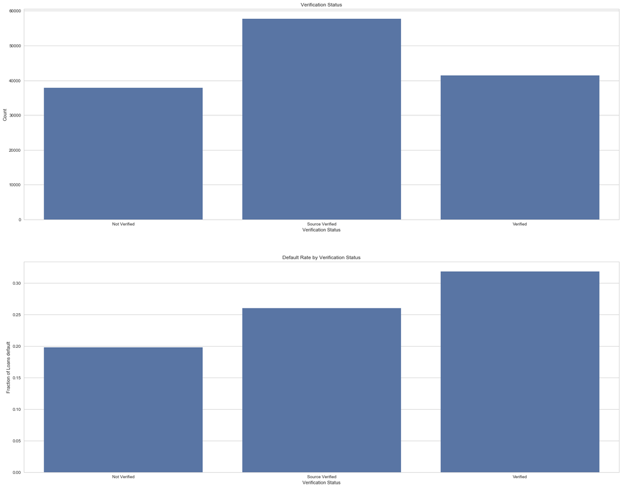

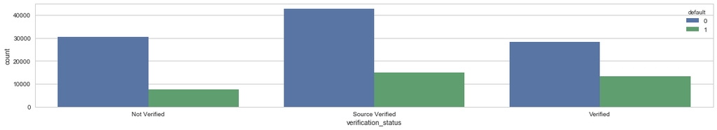

```python
plot_var('verification_status','Verification Status',False)
```

# Payment Plan

```python
len(df['pymnt_plan'].unique())
```

```
1
```

They are all the same value. So I decided to drop it.

```python
df.drop('pymnt_plan',axis=1,inplace=True)
```

# Purpose

```python
df['purpose'].value_counts()/len(df['purpose'])
```

```
debt_consolidation    0.607465
credit_card           0.208516
home_improvement      0.065990
other                 0.050629
major_purchase        0.019907
medical               0.010640
small_business        0.009319
car                   0.009166
moving                0.006677
vacation              0.006312
house                 0.004692
renewable_energy      0.000671
wedding               0.000007
educational           0.000007
Name: purpose, dtype: float64
```

Replace rare values with other purposes

```python
df['purpose'].replace({'other': 'other purpose', 'vacation': 'other purpose', 'house': 'other purpose', 'renewable_energy': 'other purpose', 'wedding': 'other purpose', 'educational':'other purpose'}, inplace =True)
```

```python
pd.DataFrame(df['purpose'].value_counts()/len(df['purpose']))
```

|  | purpose |
| --- | --- |
| debt_consolidation | 0.607465 |
| credit_card | 0.208516 |
| home_improvement | 0.065990 |
| other purpose | 0.062320 |
| major_purchase | 0.019907 |
| medical | 0.010640 |
| small_business | 0.009319 |
| car | 0.009166 |
| moving | 0.006677 |

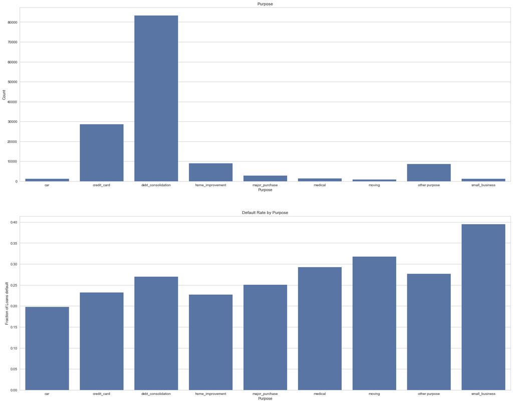

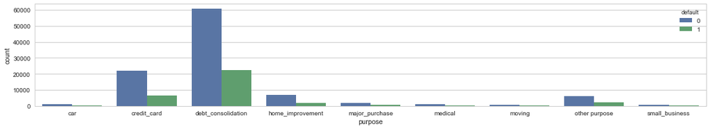

```python
plot_var('purpose','Purpose',False)
```

# Title

```python
df['title'].value_counts()
```

```
Debt consolidation                     81650
Credit card refinancing                27986
Home improvement                        8864
Other                                   6837
Major purchase                          2677
Medical expenses                        1424
Business                                1246
Car financing                           1235
Moving and relocation                    904
Vacation                                 845
Home buying                              624
Green loan                                90
Prescription Drug and Medical Costs        1
new kitchen for momma!                     1
Learning and training                      1
Trying to come back to reality!            1
Name: title, dtype: int64
```

Notice that title is very much like prupose. Drop title.

```python
df.drop('title',axis=1,inplace=True)
```

# Zip Code

```python
df['zip_code'] = df['zip_code'].apply(lambda x: int(x[:3]))
```

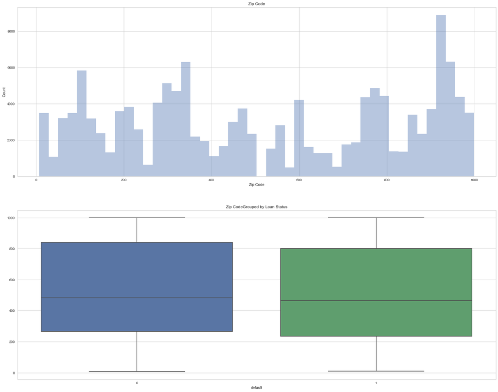

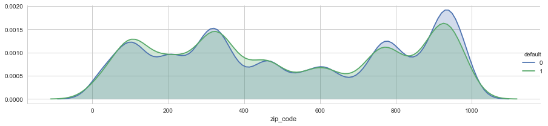

```python
plot_var('zip_code','Zip Code', True)
```

# State

```python
df['addr_state'].value_counts()
```

```
CA    20403
TX    11175
NY    10446
FL     9669
IL     4877
NJ     4668
PA     4558
OH     4402
GA     4367
NC     4094
VA     3946
MI     3714
AZ     3388
CO     3313
MD     3174
WA     3120
MA     3114
MN     2526
IN     2364
TN     2202
MO     2117
NV     2024
WI     1813
CT     1792
AL     1759
OR     1713
LA     1650
SC     1529
OK     1306
KY     1260
UT     1147
KS     1077
AR     1039
NM      804
MS      795
HI      728
NH      654
RI      581
WV      520
NE      440
MT      403
DE      371
AK      337
DC      336
SD      304
WY      292
VT      272
ME      184
ND      173
ID       95
Name: addr_state, dtype: int64
```

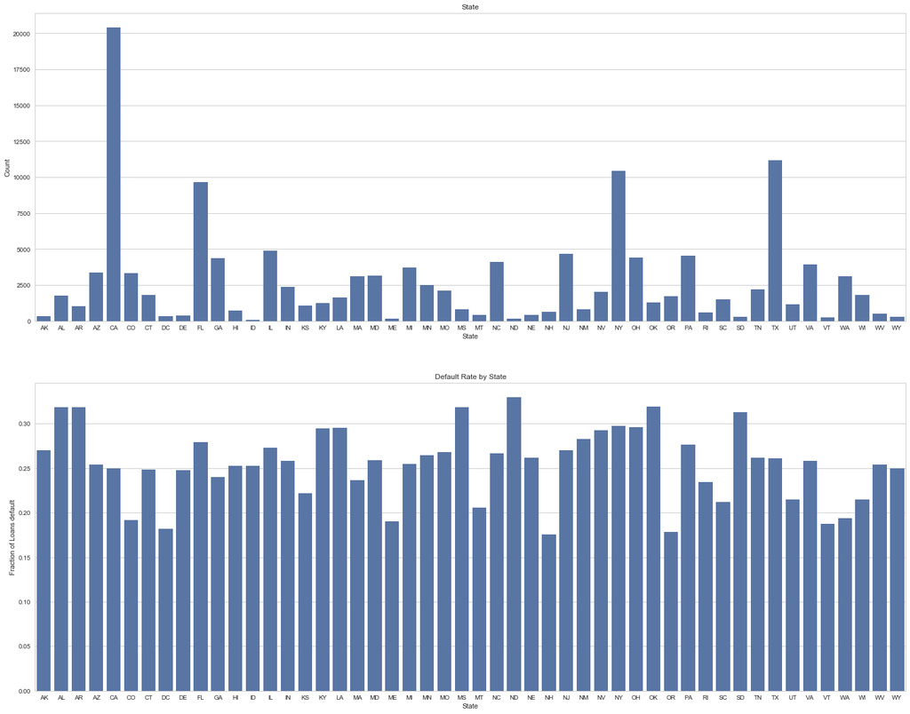

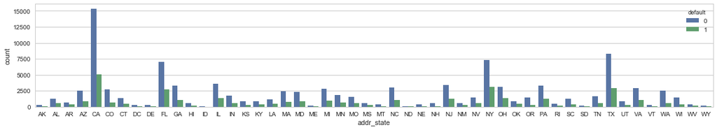

```python
plot_var('addr_state','State',False)
```

# revol_bal

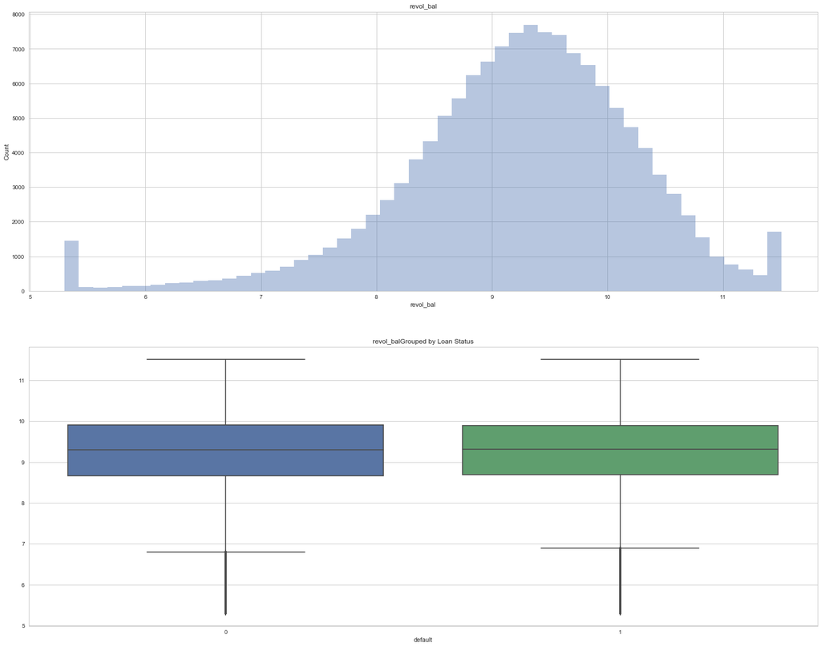

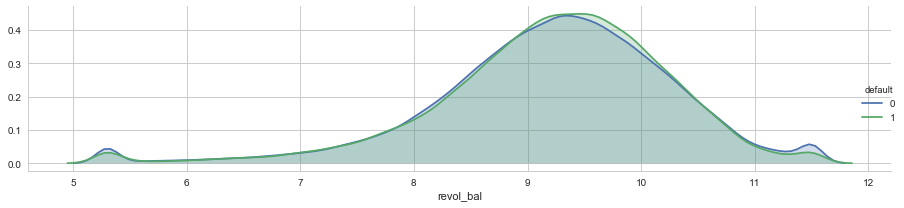

```python
high = np.percentile(df['revol_bal'], 99)
low = np.percentile(df['revol_bal'], 1)
df['revol_bal'] = df['revol_bal'].apply(lambda x: cut_outlier(high, low, x))
df['revol_bal'] = df['revol_bal'].apply(lambda x: math.log(x+1))
plot_var('revol_bal','revol_bal',True)
```

# Earliest reported crerevol_bal line was opened

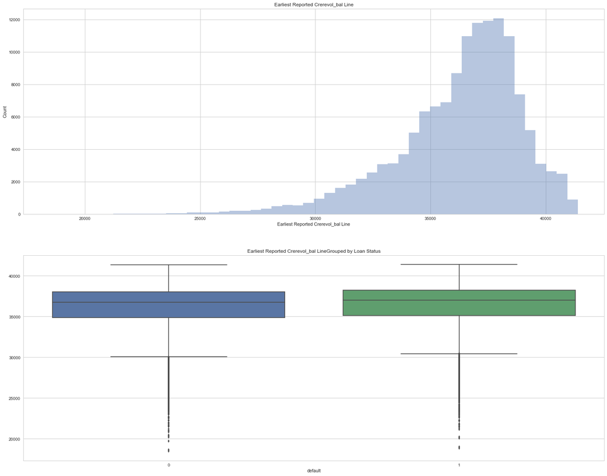

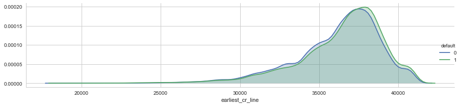

```python
plot_var('earliest_cr_line','Earliest Reported Crerevol_bal Line', True)
```

# Number of Public Records

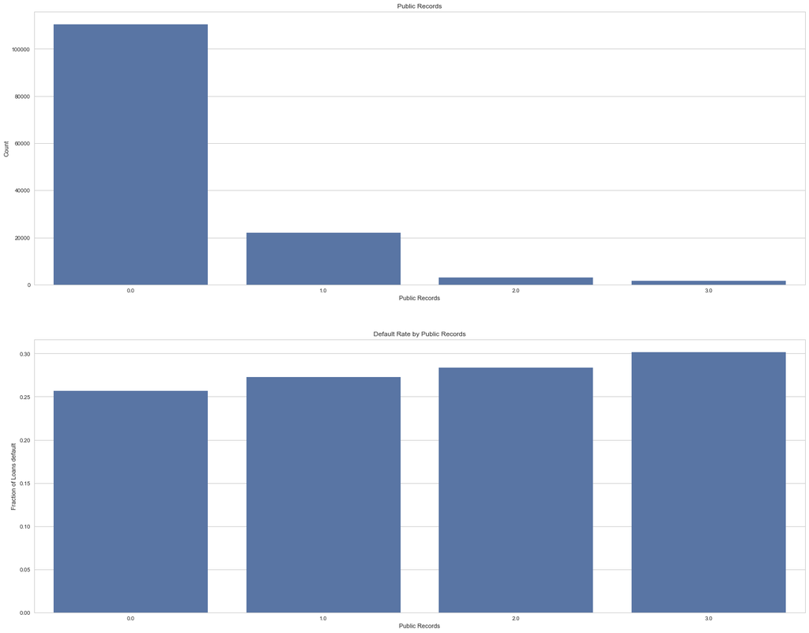

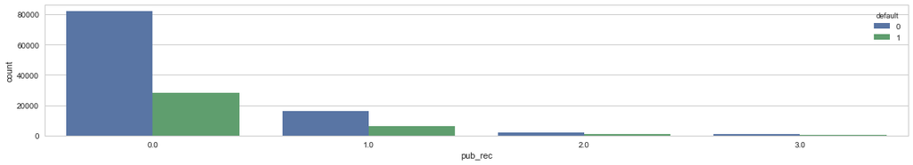

```python
high = np.percentile(df['pub_rec'], 99)
low = np.percentile(df['pub_rec'], 1)
df['pub_rec'] = df['pub_rec'].apply(lambda x: cut_outlier(high, low, x))
plot_var('pub_rec','Public Records', False)
```